```python
#imports↔
```

```
True
```

# Naive Baysian Sentiment Prediction

This is an assignment for my thinkful data science course - "naive_bayes_sentiment_prediction" Raj Prasad May 2019

[html version](https://daddyprasad5.github.io/naive_bayes_sentiment_prediction.html) - with all the code hidden away for a quick read

[jupyter notebook version](https://github.com/daddyprasad5/thinkful/blob/master/naive_bayes_sentiment_prediction.ipynb) - with all the code exposed in an interactive notebook

I've chosen to use features that are all one-hot features, each indicating presence or absence of a particular lemma in the review sentence.

I've chosen the lemmas by first finding those that most frequently occur in sentences (highest occurrence rate), and then selecting those that split sentiment best (highest split rate). When this feature selection process is applied to the imdb dataset, those features work quite nicely to predict sentiment (error rate is 16%).

I've explored generalizability by applying subsets of the process to the amazon dataset. I explored generalizability at 3 levels: same features and model; same features but new model; same feature selection process but new features and new model. The performance improves as the process is made more specific to the amazon dataset, with error rates of 32%, 20% and 13% respectively.

With some additional work some re-usable elements could be developed from the elements built here:

- the "lemmatization" of a sentence into a list of lemmas
- the "occurrence rate" calculation for lemmas in a corpus of word lists
- the "split rate" calculation for a one-hot predictor on a one-hot target variable

To further improve performance, these features could be evaluated:

- presence of punctuation types
- prevalence of punctuation types
- length of sentence
- pronouns (removed as stop words in the process used here)
- prevalence of capitals

```python
# Grab and process the raw data.↔
```

```python
#check for nulls↔
```

|  | 0 | 1 |
| --- | --- | --- |
| 0 | sentence | 0 |
| 1 | sentiment | 0 |

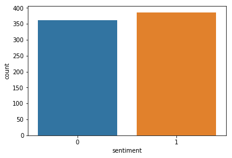

```python
#peak at the distribution - binomial seems like the right choice :)↔
```

```python
#all of the constants and functions used in this notebook↔
```

```python
#add a column of the lemmas in each sentence, and calculate the occurrence rate of each lemma↔
```

```python
#calculate how well each lemma splits sentiment and choose best splitters↔
```

```
['interesting' 'couldnt' 'awful' 'sucked' 'brilliant' 'cheap' 'poor'
 'ridiculous' 'money' 'hilarious' 'picture' 'wasted' 'terrific' 'annoying'
 'joy' 'worst' 'whatever' 'suck' 'pathetic' 'role' 'silent' 'wonderful'
 'waste' 'stupid' 'nothing' 'bad' 'played' 'loved' 'liked' 'im' 'action'
 'girl' 'place' 'word' 'hour' 'mess' 'give' 'family' 'cool' 'perfect'
 'disappointed' 'nice' 'rating' 'let' 'excellent' 'half' 'subtle' 'would'
 'lack' 'art' 'job' 'funny' 'old' 'john' 'terrible' 'beautiful' 'avoid'
 'worse' 'actually' 'level' 'memorable' 'crap' 'tom' 'guess' 'single'
 'fun' 'plot' 'lame' 'away' 'problem' 'didnt' 'cartoon' 'beyond' 'mostly'
 'fails' 'yet' 'started' 'wont' 'bit' 'performance' 'horrible' 'cost'
 'even' 'great' 'still' 'line' 'definitely' 'almost' 'white' 'cant' 'show'
 'much' 'little' 'kind' 'right' 'direction' 'cinematography' 'long' 'try'
 'said' 'truly' 'completely' 'hole' 'incredible' 'saw' 'enjoyed' 'love'
 'year' 'minute' 'short' 'play' 'script' 'think' 'comedy' 'portrayal'
 'sound' 'must' 'especially' 'certainly' 'far' 'used' 'special' 'everyone'
 'set' 'anything' 'cinema' '1' 'least' 'thing' 'predictable' 'however'
 'best' 'worth' 'writing' 'go' 'people' 'music' 'well' 'good' 'second'
 'id' 'totally' 'attempt' 'use' 'quite' 'style' 'believable' 'tv' 'game'
 'two' 'director' 'thriller' 'casting' 'face' 'recommended' 'rather'
 'come' 'history' 'playing' 'highly' 'actress' 'hitchcock' 'entire' 'cast'
 'classic' 'ha' 'many' 'dont' 'ending' 'man' 'find' 'dialogue' 'piece'
 'though' 'character' 'actor' 'also' 'thats' 'simply' 'drama' 'child'
 'fan' 'kid' 'camera' 'directing' 'shot' 'boring' 'could' 'work' '10'
 'film' 'care' 'felt' 'audience' '\x96' 'day' 'talk' '0' 'budget' 'since'
 'amazing' 'put' 'new' 'eye' 'strong' 'enjoy' 'moment' 'turn' 'overall'
 'gave' 'full' 'see' 'night' 'world' 'u' 'lead' 'amount' 'clever' 'every'
 'first' 'done' 'another' 'around' 'flick' 'editing' 'enough' 'part'
 'mention' 'solid' 'seen' 'say' 'everything' 'recommend' 'life' 'doesnt'
 'ive' 'really' 'human' 'time' 'experience' 'written' 'garbage' 'want'
 'wasnt' 'probably' 'series' 'seeing' 'suspense' 'horror' 'together'
 'found' 'fact' 'screen' 'song' 'way' 'better' 'never' 'big' 'absolutely'
 'get' 'understand' 'feeling' 'watching' 'acting' 'going' 'doe' 'black'
 'effect' 'real' 'one' 'ever' 'end' 'look' 'made' 'scene' 'story' 'like'
 'pretty' 'make' 'anyone' 'wa' 'watch' '' 'movie']
```

```python
#create features using the top splitting lemmas and add them to the dataframe↔
```

```python
#test to see how many sentences have any of the features I've selected↔
```

```
hit rate is  0.9625668449197861
```

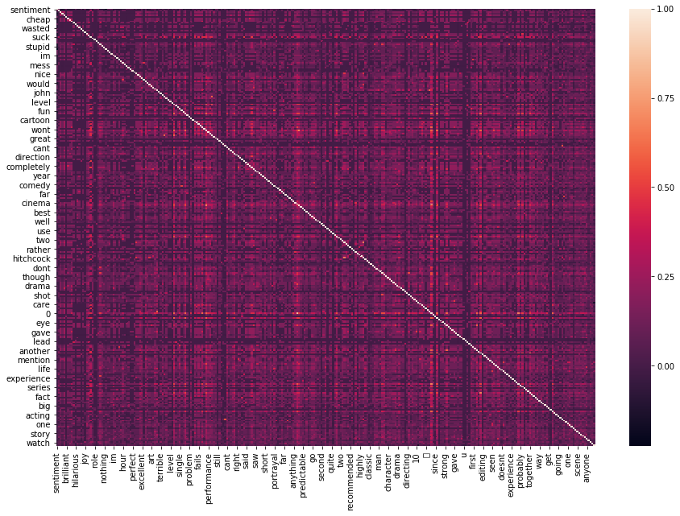

```python
#test for correlation between feature pairs - looks pretty good (i.e. low correlation)↔
```

```python
#train and evaluate the model↔
```

```
error rate is  0.16310160427807488
```

```
hit rate is  0.869
```

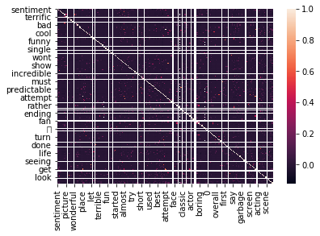

```
error rate is  0.318
```

```python
#test the prediction process on a new dataset - the amazon reviews - using the same features and trained model↔
```

```
hit rate is  0.869
```

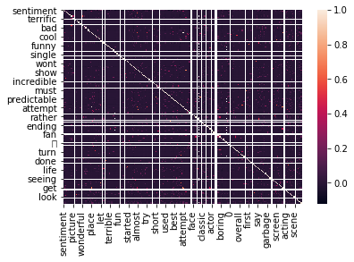

```
error rate is  0.201
```

```python
#use the same features but a new model trained on the new data↔
```

```
['horrible' 'suck' 'none' 'order' 'nice' 'love' 'break' 'definitely'
 'family' 'crap' 'pleased' 'comfortably' 'disappointing' 'seller' 'waste'
 'weak' 'worst' 'charm' 'bad' 'awesome' 'range' 'anything' 'poor' 'old'
 'buying' 'return' 'sturdy' 'priced' 'unreliable' 'free' 'fast' 'later'
 'leather' 'support' 'keyboard' 'seems' 'didnt' 'hate' 'useless' 'junk'
 'pc' 'broke' 'drain' 'perfectly' 'unit' 'difficult' 'value' 'mistake'
 'terrible' 'disappointed' 'instruction' 'easily' 'disappointment'
 'excellent' 'money' 'great' 'price' 'fine' 'best' 'customer' 'pretty'
 'highly' 'first' 'doesnt' 'however' 'back' 'jabra' 'without' 'happy'
 'company' 'completely' 'talk' 'stay' 'went' 'cant' 'hand' 'piece' 'hear'
 'want' 'anyone' 'come' 'put' 'drop' 'within' '5' 'clear' 'dont' 'easy'
 'good' 'working' 'well' 'could' 'comfortable' 'conversation' 'kind'
 'tool' 'clarity' 'samsung' 'place' 'cannot' 'player' 'button' 'week'
 'lot' 'quickly' '3' 'plastic' 'especially' 'shipping' 'others' 'job'
 'started' 'original' 'device' 'charge' 'wear' 'everything' 'cool' 'take'
 'call' 'recommend' 'far' 'enough' 'left' 'choice' 'kept' 'sending' 'must'
 'decent' '1' 'pocket' 'contact' 'plan' 'blue' 'data' 'absolutely' 'face'
 'purchased' 'never' 'lightweight' 'id' 'either' 'found' 'obviously'
 'design' 'plug' 'able' 'plantronics' 'bargain' 'ago' 'noise' 'easier'
 'buy' 'thing' 'last' 'camera' 'doe' 'still' 'cell' 'big' 'turn' 'signal'
 'nokia' 'way' 'bluetooth' 'ha' 'fit' 'got' 'ever' 'case' 'bar' 'going'
 'dropped' 'minute' 'volume' 'go' 'loud' 'headphone' 'black' 'keep' 'real'
 'side' 'work' 'year' 'several' 'came' 'simple' 'color' 'need' 'service'
 'sound' 'car' 'ive' 'month' 'quality' 'charger' 'new' 'voice' 'small'
 'feature' 'tried' 'light' 'cheap' 'feel' 'little' 'headset' 'time' 'even'
 'better' 'make' 'size' 'hard' 'always' 'like' 'connection' 'part' 'try'
 'thats' 'three' 'charging' 'think' 'helpful' 'sure' 'picture' 'belt'
 'clip' 'different' 'people' 'arrived' 'expect' 'high' 'strong' 'razr'
 'reception' 'important' 'purchase' 'couple' '' 'product' 'using' 'much'
 'life' 'problem' 'right' 'one' 'really' 'wa' 'since' 'quite' 'made'
 'hour' 'earpiece' 'find' 'end' 'audio' 'two' 'cable' 'bought' 'get'
 'look' 'say' 'impressed' 'hold' 'low' 'amazon' 'item' 'couldnt' 'long'
 'motorola' 'day' 'phone']
hit rate is  0.953
```

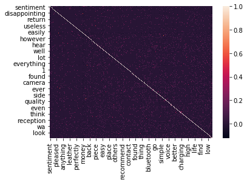

```
error rate is  0.133
```

```python
#use new features and a new model, but follow the same general process↔
```